# Prosper Loan Data Analysis

## Introduction

> The Prosper Loan dataset contains 113,937 loans with 81 variables on each loan, including loan amount, borrower rate (or interest rate), current loan status, borrower income, and many others.

## Preliminary Wrangling

```python
# import all packages and set plots to be embedded inline
import numpy as np
import pandas as pd
import matplotlib.pyplot as plt
import seaborn as sb
from pandas.api.types import CategoricalDtype

%matplotlib inline
```

```python
#load in dataset
df = pd.read_csv("prosperLoanData.csv")
```

```python
#Overview of data shape and composition
df.shape
```

```
(113937, 81)
```

```python
df.head()
```

|  | ListingKey | ListingNumber | ListingCreationDate | CreditGrade | Term | LoanStatus | ClosedDate | BorrowerAPR | BorrowerRate | LenderYield | ... | LP_ServiceFees | LP_CollectionFees | LP_GrossPrincipalLoss | LP_NetPrincipalLoss | LP_NonPrincipalRecoverypayments | PercentFunded | Recommendations | InvestmentFromFriendsCount | InvestmentFromFriendsAmount | Investors |
| --- | --- | --- | --- | --- | --- | --- | --- | --- | --- | --- | --- | --- | --- | --- | --- | --- | --- | --- | --- | --- | --- |
| 0 | 1021339766868145413AB3B | 193129 | 2007-08-26 19:09:29.263000000 | C | 36 | Completed | 2009-08-14 00:00:00 | 0.16516 | 0.1580 | 0.1380 | ... | -133.18 | 0.0 | 0.0 | 0.0 | 0.0 | 1.0 | 0 | 0 | 0.0 | 258 |
| 1 | 10273602499503308B223C1 | 1209647 | 2014-02-27 08:28:07.900000000 | NaN | 36 | Current | NaN | 0.12016 | 0.0920 | 0.0820 | ... | 0.00 | 0.0 | 0.0 | 0.0 | 0.0 | 1.0 | 0 | 0 | 0.0 | 1 |
| 2 | 0EE9337825851032864889A | 81716 | 2007-01-05 15:00:47.090000000 | HR | 36 | Completed | 2009-12-17 00:00:00 | 0.28269 | 0.2750 | 0.2400 | ... | -24.20 | 0.0 | 0.0 | 0.0 | 0.0 | 1.0 | 0 | 0 | 0.0 | 41 |
| 3 | 0EF5356002482715299901A | 658116 | 2012-10-22 11:02:35.010000000 | NaN | 36 | Current | NaN | 0.12528 | 0.0974 | 0.0874 | ... | -108.01 | 0.0 | 0.0 | 0.0 | 0.0 | 1.0 | 0 | 0 | 0.0 | 158 |
| 4 | 0F023589499656230C5E3E2 | 909464 | 2013-09-14 18:38:39.097000000 | NaN | 36 | Current | NaN | 0.24614 | 0.2085 | 0.1985 | ... | -60.27 | 0.0 | 0.0 | 0.0 | 0.0 | 1.0 | 0 | 0 | 0.0 | 20 |

5 rows × 81 columns

```python
df.info()
```

```
<class 'pandas.core.frame.DataFrame'>
RangeIndex: 113937 entries, 0 to 113936
Data columns (total 81 columns):
ListingKey                             113937 non-null object
ListingNumber                          113937 non-null int64
ListingCreationDate                    113937 non-null object
CreditGrade                            28953 non-null object
Term                                   113937 non-null int64
LoanStatus                             113937 non-null object
ClosedDate                             55089 non-null object
BorrowerAPR                            113912 non-null float64
BorrowerRate                           113937 non-null float64
LenderYield                            113937 non-null float64
EstimatedEffectiveYield                84853 non-null float64
EstimatedLoss                          84853 non-null float64
EstimatedReturn                        84853 non-null float64
ProsperRating (numeric)                84853 non-null float64
ProsperRating (Alpha)                  84853 non-null object
ProsperScore                           84853 non-null float64
ListingCategory (numeric)              113937 non-null int64
BorrowerState                          108422 non-null object
Occupation                             110349 non-null object
EmploymentStatus                       111682 non-null object
EmploymentStatusDuration               106312 non-null float64
IsBorrowerHomeowner                    113937 non-null bool
CurrentlyInGroup                       113937 non-null bool
GroupKey                               13341 non-null object
DateCreditPulled                       113937 non-null object
CreditScoreRangeLower                  113346 non-null float64
CreditScoreRangeUpper                  113346 non-null float64
FirstRecordedCreditLine                113240 non-null object
CurrentCreditLines                     106333 non-null float64
OpenCreditLines                        106333 non-null float64
TotalCreditLinespast7years             113240 non-null float64
OpenRevolvingAccounts                  113937 non-null int64
OpenRevolvingMonthlyPayment            113937 non-null float64
InquiriesLast6Months                   113240 non-null float64
TotalInquiries                         112778 non-null float64
CurrentDelinquencies                   113240 non-null float64
AmountDelinquent                       106315 non-null float64
```

[output cut: 31 more lines]

```
LP_CustomerPayments                    113937 non-null float64
LP_CustomerPrincipalPayments           113937 non-null float64
LP_InterestandFees                     113937 non-null float64
LP_ServiceFees                         113937 non-null float64
LP_CollectionFees                      113937 non-null float64
LP_GrossPrincipalLoss                  113937 non-null float64
LP_NetPrincipalLoss                    113937 non-null float64
LP_NonPrincipalRecoverypayments        113937 non-null float64
PercentFunded                          113937 non-null float64
Recommendations                        113937 non-null int64
InvestmentFromFriendsCount             113937 non-null int64
InvestmentFromFriendsAmount            113937 non-null float64
Investors                              113937 non-null int64
dtypes: bool(3), float64(50), int64(11), object(17)
memory usage: 68.1+ MB
```

#### Data Cleaning

There are several columns in the original dataset I won't be working with, and some of the columns need to be cleaned. I am focusing my analysis on listings that were posted in 2009 and after that, since the data consists on data that wer sort of segmented into periods, pre-2009 and 2009 and above.

```python
#Variables of interest
loan_df = df[["ListingNumber", "ListingCreationDate", "LoanOriginationDate", "ProsperRating (Alpha)",
   "Term", "LoanStatus", "BorrowerRate", "ProsperScore", "ListingCategory (numeric)", "BorrowerState",
    "EmploymentStatus", "StatedMonthlyIncome", "MonthlyLoanPayment", "LoanOriginalAmount", "IncomeRange",
    "DebtToIncomeRatio", "IsBorrowerHomeowner", "CreditScoreRangeLower", "CreditScoreRangeUpper"]]
loan_df.head(2)
```

|  | ListingNumber | ListingCreationDate | LoanOriginationDate | ProsperRating (Alpha) | Term | LoanStatus | BorrowerRate | ProsperScore | ListingCategory (numeric) | BorrowerState | EmploymentStatus | StatedMonthlyIncome | MonthlyLoanPayment | LoanOriginalAmount | IncomeRange | DebtToIncomeRatio | IsBorrowerHomeowner | CreditScoreRangeLower | CreditScoreRangeUpper |
| --- | --- | --- | --- | --- | --- | --- | --- | --- | --- | --- | --- | --- | --- | --- | --- | --- | --- | --- | --- |
| 0 | 193129 | 2007-08-26 19:09:29.263000000 | 2007-09-12 00:00:00 | NaN | 36 | Completed | 0.158 | NaN | 0 | CO | Self-employed | 3083.333333 | 330.43 | 9425 | $25,000-49,999 | 0.17 | True | 640.0 | 659.0 |
| 1 | 1209647 | 2014-02-27 08:28:07.900000000 | 2014-03-03 00:00:00 | A | 36 | Current | 0.092 | 7.0 | 2 | CO | Employed | 6125.000000 | 318.93 | 10000 | $50,000-74,999 | 0.18 | False | 680.0 | 699.0 |

```python
#check for duplicates.
#Since the listing numbers are unique, I will check for duplicates based on that
loan_df["ListingNumber"].duplicated().sum()
```

```
871
```

```python
#drop duplicates

dup_index = loan_df[loan_df["ListingNumber"].duplicated() == True].index

loan_df = loan_df.drop(loan_df.index[loan_df.index.isin(list(dup_index))])
```

```python
#get summary of the data
loan_df.info()
```

```
<class 'pandas.core.frame.DataFrame'>
Int64Index: 113066 entries, 0 to 113936
Data columns (total 19 columns):
ListingNumber                113066 non-null int64
ListingCreationDate          113066 non-null object
LoanOriginationDate          113066 non-null object
ProsperRating (Alpha)        83982 non-null object
Term                         113066 non-null int64
LoanStatus                   113066 non-null object
BorrowerRate                 113066 non-null float64
ProsperScore                 83982 non-null float64
ListingCategory (numeric)    113066 non-null int64
BorrowerState                107551 non-null object
EmploymentStatus             110811 non-null object
StatedMonthlyIncome          113066 non-null float64
MonthlyLoanPayment           113066 non-null float64
LoanOriginalAmount           113066 non-null int64
IncomeRange                  113066 non-null object
DebtToIncomeRatio            104594 non-null float64
IsBorrowerHomeowner          113066 non-null bool
CreditScoreRangeLower        112475 non-null float64
CreditScoreRangeUpper        112475 non-null float64
dtypes: bool(1), float64(7), int64(4), object(7)
memory usage: 16.5+ MB
```

```python
#convert to the right datatypes
loan_df["ListingCreationDate"] = pd.to_datetime(loan_df["ListingCreationDate"])
loan_df["LoanOriginationDate"] = pd.to_datetime(loan_df["LoanOriginationDate"])
loan_df["ListingCategory (numeric)"] = loan_df["ListingCategory (numeric)"].astype("category")
loan_df["LoanStatus"] = loan_df["LoanStatus"].astype("category")
loan_df["IncomeRange"] = loan_df["IncomeRange"].astype("category")
loan_df["EmploymentStatus"] = loan_df["EmploymentStatus"].astype("category")
loan_df["ProsperScore"] = loan_df["ProsperScore"].astype("category")
```

```python
# convert ProsperRating (Alpha) to ordinal category type
order = ['AA', 'A', 'B', 'C', 'D', 'E','HR']
ordered_cat = pd.api.types.CategoricalDtype(categories=order, ordered=True)
loan_df['ProsperRating (Alpha)'] = loan_df['ProsperRating (Alpha)'].astype(ordered_cat)
```

```python
#select only listings from 2009 upwards
loan_df2 = loan_df[(loan_df.ListingCreationDate.dt.year >= 2009)]
loan_df2.shape
```

```
(84010, 19)
```

```python
#Check for missing values
loan_df2.isna().sum()
```

```
ListingNumber                   0
ListingCreationDate             0
LoanOriginationDate             0
ProsperRating (Alpha)          28
Term                            0
LoanStatus                      0
BorrowerRate                    0
ProsperScore                   28
ListingCategory (numeric)       0
BorrowerState                   0
EmploymentStatus                0
StatedMonthlyIncome             0
MonthlyLoanPayment              0
LoanOriginalAmount              0
IncomeRange                     0
DebtToIncomeRatio            7215
IsBorrowerHomeowner             0
CreditScoreRangeLower           0
CreditScoreRangeUpper           0
dtype: int64
```

```python
#Select ProsperRating and DebtToIncomeRatio that is not null
loan_df2 = loan_df2[(loan_df2["ProsperRating (Alpha)"].isna() == False) & (loan_df2["DebtToIncomeRatio"].isna() == False)]

loan_df2.isna().sum()
```

```
ListingNumber                0
ListingCreationDate          0
LoanOriginationDate          0
ProsperRating (Alpha)        0
Term                         0
LoanStatus                   0
BorrowerRate                 0
ProsperScore                 0
ListingCategory (numeric)    0
BorrowerState                0
EmploymentStatus             0
StatedMonthlyIncome          0
MonthlyLoanPayment           0
LoanOriginalAmount           0
IncomeRange                  0
DebtToIncomeRatio            0
IsBorrowerHomeowner          0
CreditScoreRangeLower        0
CreditScoreRangeUpper        0
dtype: int64
```

```python
#view a statistical summary of the numerical variables
loan_df2.describe()
```

|  | ListingNumber | Term | BorrowerRate | StatedMonthlyIncome | MonthlyLoanPayment | LoanOriginalAmount | DebtToIncomeRatio | CreditScoreRangeLower | CreditScoreRangeUpper |
| --- | --- | --- | --- | --- | --- | --- | --- | --- | --- |
| count | 7.676800e+04 | 76768.000000 | 76768.000000 | 76768.000000 | 76768.000000 | 76768.000000 | 76768.000000 | 76768.000000 | 76768.000000 |
| mean | 7.761845e+05 | 42.701230 | 0.193653 | 5964.256138 | 295.275039 | 9248.961416 | 0.258692 | 699.088422 | 718.088422 |
| std | 2.354251e+05 | 11.710835 | 0.074018 | 5089.682309 | 189.109061 | 6389.782292 | 0.319727 | 47.250315 | 47.250315 |
| min | 4.162750e+05 | 12.000000 | 0.040000 | 0.250000 | 0.000000 | 1000.000000 | 0.000000 | 600.000000 | 619.000000 |
| 25% | 5.613232e+05 | 36.000000 | 0.134900 | 3528.895834 | 158.330000 | 4000.000000 | 0.150000 | 660.000000 | 679.000000 |
| 50% | 7.458110e+05 | 36.000000 | 0.184500 | 5000.000000 | 256.120000 | 8000.000000 | 0.220000 | 700.000000 | 719.000000 |
| 75% | 9.794395e+05 | 60.000000 | 0.254900 | 7166.666667 | 392.010000 | 14000.000000 | 0.320000 | 720.000000 | 739.000000 |
| max | 1.255149e+06 | 60.000000 | 0.360000 | 483333.333333 | 2251.510000 | 35000.000000 | 10.010000 | 880.000000 | 899.000000 |

```python
#Replace the numeric values in ListingCategory (numeric) with their actual values
loan_df2["ListingCategory (numeric)"] = loan_df2["ListingCategory (numeric)"].replace([ 0,1,2,3,4,5,6,7,8,9,10,11,12,13,14,15,16,17,18,19,20],
                                                                                    ["Not Available", "Debt Consolidation", "Home Improvement", "Business", "Personal Loan", "Student Use", "Auto", "Other",
                                                                                     "Baby&Adoption", "Boat", "Cosmetic Procedure", "Engagement Ring", "Green Loans", "Household Expenses", "Large Purchases",
                                                                                     "Medical/Dental", "Motorcycle", "RV", "Taxes", "Vacation", "Wedding Loans"])

#Rename ProsperRating (Alpha) and ListingCategory (numeric) for consistency
loan_df2.rename(columns={"ListingCategory (numeric)": "ListingCategory", "ProsperRating (Alpha)": "ProsperRating"}, inplace=True)
loan_df2["ListingCategory"] = loan_df2["ListingCategory"].astype("category")
loan_df2.columns
```

```
Index(['ListingNumber', 'ListingCreationDate', 'LoanOriginationDate',
       'ProsperRating', 'Term', 'LoanStatus', 'BorrowerRate', 'ProsperScore',
       'ListingCategory', 'BorrowerState', 'EmploymentStatus',
       'StatedMonthlyIncome', 'MonthlyLoanPayment', 'LoanOriginalAmount',
       'IncomeRange', 'DebtToIncomeRatio', 'IsBorrowerHomeowner',
       'CreditScoreRangeLower', 'CreditScoreRangeUpper'],
      dtype='object')
```

```python
#Create a column that contains the average of bothe credit score ranges
loan_df2["CreditScoreAverage"] = (loan_df2["CreditScoreRangeUpper"] + loan_df2["CreditScoreRangeLower"])/2
```

```python
#Drop columns that are no longer needed
loan_df2 = loan_df2.drop(columns=["CreditScoreRangeUpper", "CreditScoreRangeLower"], axis=1)
```

```python
#Create credit score groups based on nerdwallet
bin_edges = [300,630,690,720,850]
bin_names = ["Bad", "Fair", "Good", "Excellent"]
loan_df2["CreditScoreLevel"] = pd.cut(loan_df2["CreditScoreAverage"], bin_edges, labels=bin_names)
loan_df2["CreditScoreLevel"].value_counts()
```

```
Fair         33921
Excellent    28175
Good         12124
Bad           2420
Name: CreditScoreLevel, dtype: int64
```

```python
loan_df2.info()
```

```
<class 'pandas.core.frame.DataFrame'>
Int64Index: 76768 entries, 1 to 113936
Data columns (total 19 columns):
ListingNumber          76768 non-null int64
ListingCreationDate    76768 non-null datetime64[ns]
LoanOriginationDate    76768 non-null datetime64[ns]
ProsperRating          76768 non-null category
Term                   76768 non-null int64
LoanStatus             76768 non-null category
BorrowerRate           76768 non-null float64
ProsperScore           76768 non-null category
ListingCategory        76768 non-null category
BorrowerState          76768 non-null object
EmploymentStatus       76768 non-null category
StatedMonthlyIncome    76768 non-null float64
MonthlyLoanPayment     76768 non-null float64
LoanOriginalAmount     76768 non-null int64
IncomeRange            76768 non-null category
DebtToIncomeRatio      76768 non-null float64
IsBorrowerHomeowner    76768 non-null bool
CreditScoreAverage     76768 non-null float64
CreditScoreLevel       76640 non-null category
dtypes: bool(1), category(7), datetime64[ns](2), float64(5), int64(3), object(1)
memory usage: 7.6+ MB
```

```python
loan_df2.shape
```

```
(76768, 19)
```

### What is the structure of your dataset?

> The original dataset contains 113937 rows and 81 columns. However, I will be working with a subset that contains 76,768 rows and 19 columns. Most of the features are numeric, and ProsperRating and ProsperScore are ordered in the following manner:

(worst) ---> (best)

- ProsperScore: 1,2,3,4,5,6,7,8,9,10,11
- ProsperRating: HR,E,D,C,B,A,AA

### What is/are the main feature(s) of interest in your dataset?

> I am interested in the borrower rate and loan original amount, I want to see what features might influence them

### What features in the dataset do you think will help support your investigation into your feature(s) of interest?

> I think Prosper score, prosper rating , credit score, employment status, income range, debt to income ratio amd the term of a loan might affect both borrower rate and the loan amount granted. O ther features will also be investigated.

## Univariate Exploration

First, I will take a look at the distribution of my main variables of interest, BorrowerRate and LoanOriginalAmount

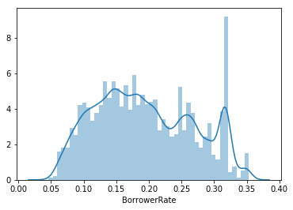

```python
#Histogram of BorrowerRate
sb.distplot(loan_df2.BorrowerRate);
```

The histogram shows a multimodal distribution, with peak values around 0.14, 0.26 and a sharp peak around 0.32. It shows most of the loans in the dataset have borrower rates around 0.26 and below.

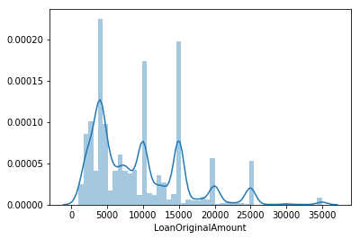

```python
#Histogram for LoanOriginalAmount
sb.distplot(loan_df2["LoanOriginalAmount"]);
```

The Loan original amount has a multimodal distribution, with peaks around \$4K, \\$10K, \$15K, \\$20K, \$35K and the curve kind of flattens around \\$30K. These peak values occur almost in 5 thousands, almost like borrowers would 'round-up' their loan amounts.Most of the loans taken have values less that \$10,000, very few loans have values greater than $26,000

Now, I will examine the distributions of the other features

```python
base_color = sb.color_palette()[0]
total = loan_df2["ProsperRating"].value_counts().sum()
def TextProp(col):
    '''
    Function to add proportion text to bar charts
    '''
    col_counts = loan_df2[col].value_counts()
    # Logic to print the proportion text on the bars
    for i in range (col_counts.shape[0]):
        count = col_counts[i]
        # Convert count into a percentage, and then into string
        pct_string = '{:0.3f}%'.format(100*count/total)
        # Print the string value on the bar.
        plt.text(count+1, i, pct_string, va='center')
```

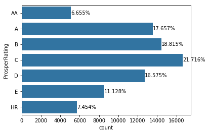

```python
#Distribution of ProsperRating
sb.countplot(data=loan_df2, y=loan_df2["ProsperRating"], color=base_color)
TextProp("ProsperRating");
```

The bar chart for ProsperRating shows that the most popular Prosper Rating is "C", which is the center value. A very small proportion of the borrowers have ratings at the extreme ends("AA", "HR")

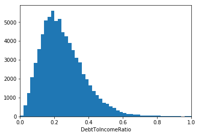

```python
#Distribution of DebtToIncomeRatio
bins = np.arange(0, loan_df2['DebtToIncomeRatio'].max()+0.02, 0.02)
plt.hist(loan_df2["DebtToIncomeRatio"], bins=bins)
plt.xlim(0,1)
plt.xlabel("DebtToIncomeRatio");
```

The distribution is right-skewed, with a peak value between 0.1 and 0.2. From thne long tail of the histogram, we can see that very few borrowers have debt to income ratio greater than 0.6, most have ratios less than 0.4. Later on, I will see how this relates with the loan amount

```python
#Distribution of income range
loan_df2["IncomeRange"].value_counts()
```

```
$50,000-74,999    23756
$25,000-49,999    21795
$100,000+         13889
$75,000-99,999    13519
$1-24,999          3808
Not employed          1
Not displayed         0
$0                    0
Name: IncomeRange, dtype: int64
```

For the income range, there is a range of \$0 and also "Not employed". It is expected that unemployed individuals will have \\$0 income, so I will join these two categories together

```python
AdjustedIncomeRange = []
for status in loan_df2["IncomeRange"]:
    if status in ["$0", "Not employed"]:
        status = "$0"
    else:
        status = status
    AdjustedIncomeRange.append(status)

loan_df2["IncomeRange"] = AdjustedIncomeRange
```

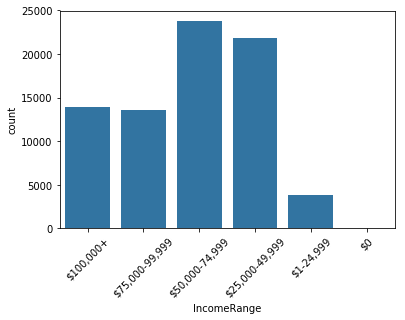

```python
#Distribution of the adjusted income range
order = ["$100,000+", "$75,000-99,999", "$50,000-74,999", "$25,000-49,999", "$1-24,999", "$0"]
sb.countplot(data=loan_df2, x=loan_df2["IncomeRange"], order=order, color=base_color)
plt.xticks(rotation=45);
```

Most of the borrowers are middle income earners(\$25K - \\$74,999), then high income(\$75K-\\$100K+) and lastly low income(<\$25K)

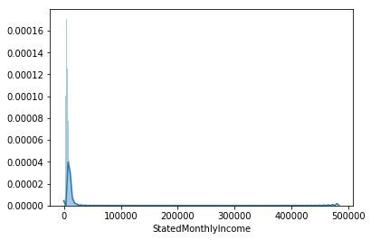

```python
#Distribution of StatedMonthlyIncome
sb.distplot(loan_df2.StatedMonthlyIncome, bins=500);
```

The histogram shows presence of outliers. I will zoom in on values between 0 and \$20K to get a better view of the distribution

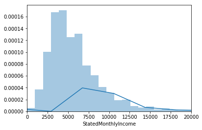

```python
#Distribution of StatedMonthlyIncome
sb.distplot(loan_df2.StatedMonthlyIncome, bins=500)
plt.xlim(0,20000);
```

Most of the borrowers earn less than \$100,000. So, having a borrower earn almost \\$500,000 monthly is unusual. I focused on the earnings less than \$20,000. From the histogram, I can now see that the peak earning point is at \\$5,000, and most earnings are between \$2,500 and \\$12,500 monthly.

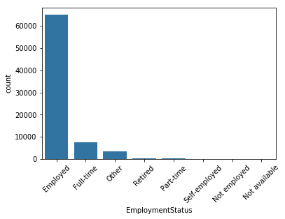

```python
#Distribution of employment status
employment_order = loan_df2["EmploymentStatus"].value_counts().index
sb.countplot(data=loan_df2, x=loan_df2["EmploymentStatus"], order=employment_order, color=base_color);
plt.xticks(rotation=45);
```

Having "Employed", "Full-time" and "Part-time" gives confusing results. I will join the 3 categories to form "Employed"

```python
AdjustedEmploymentStatus = []
for status in loan_df2["EmploymentStatus"]:
    if status in ["Employed", "Full-time", "Part-time"]:
        status = "Employed"
    else:
        status = status
    AdjustedEmploymentStatus.append(status)

loan_df2["EmploymentStatus"] = AdjustedEmploymentStatus
```

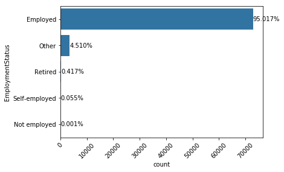

```python
#Distribution of employment status
employment_order = loan_df2["EmploymentStatus"].value_counts().index
sb.countplot(data=loan_df2, y=loan_df2["EmploymentStatus"], order=employment_order, color=base_color)
plt.xticks(rotation=45)

TextProp("EmploymentStatus")
```

Employed individuals took 95.017% of loans in this dataset,which makes sense because they have an income and are more likely to be able to pay back.

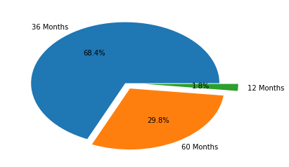

```python
#Distribution of terms
plt.pie(loan_df2["Term"].value_counts(), labels=["36 Months", "60 Months", "12 Months"], autopct='%1.1f%%', explode=(0, 0.1, 0.2));
```

The piechart shows that 68.4% of the loans have a term of 36 months, 29.8% have a term of 60 months and only 1.8% have a term of 12 months

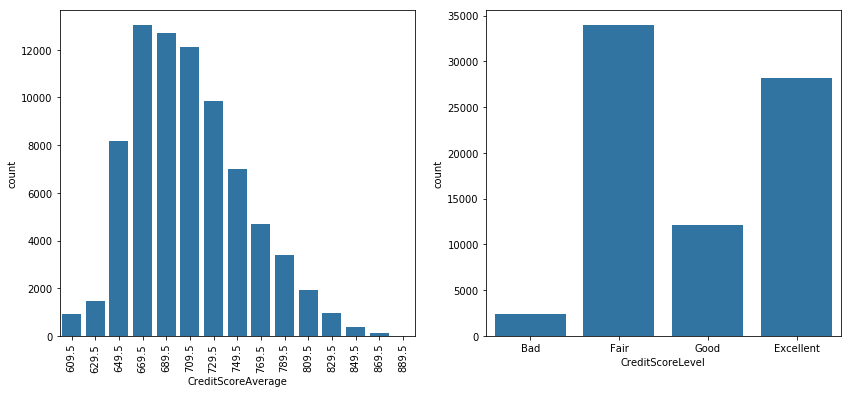

```python
#Distribution of CreditScoreAverage
plt.figure(figsize=(14,6))
plt.subplot(1,2,1)
sb.countplot(data=loan_df2, x=loan_df2["CreditScoreAverage"], color=base_color)
plt.xticks(rotation=90)

plt.subplot(1,2,2)
sb.countplot(data=loan_df2, x=loan_df2["CreditScoreLevel"], color=base_color);
```

The most popular credit score level is "Fair"(630-689), followed by "Excellent"(720-850), then "Good"(690-719), and a small number of borrowers had "Bad"(300-629) credit scores. The distribution of the credit score average is right-skewed.

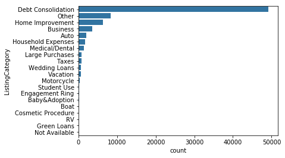

```python
#Distribution of ListingCategory
listing_order = loan_df2["ListingCategory"].value_counts().index
sb.countplot(data=loan_df2, y=loan_df2["ListingCategory"], order=listing_order, color=base_color);
```

The most common listing category is Debt Consolidation

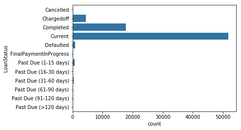

```python
#Distribution of loan status
sb.countplot(data=loan_df2, y=loan_df2["LoanStatus"], color=base_color);
```

Since the number of entries in all the 'Past Due' categories are small, I will record each value as 'Past Due'

```python
AdjustedLoanStatus = []
for status in loan_df2["LoanStatus"]:
    if status in ["Past Due (1-15 days)", "Past Due (31-60 days)", "Past Due (61-90 days)", "Past Due (91-120 days)",
                  "Past Due (16-30 days)", "Past Due (>120 days)"]:
        status = "Past Due"
    else:
        status = status
    AdjustedLoanStatus.append(status)

loan_df2["LoanStatus"] = AdjustedLoanStatus
```

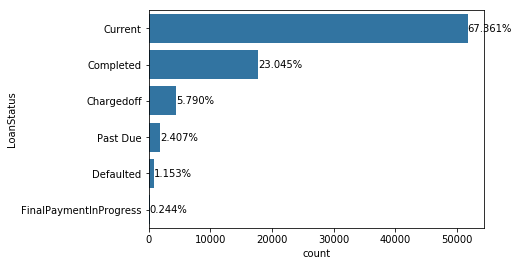

```python
status_order = loan_df2["LoanStatus"].value_counts().index
sb.countplot(data=loan_df2, y=loan_df2["LoanStatus"], order=status_order, color=base_color)
TextProp("LoanStatus")
```

67.4% of loans in this dataset are still ongoing(current), 23% of loans have been completed, 5.8% were recorded as bad loans(charged off), total of 2.4% were already past their due date, 1.2% Defaulted and a very small amount(0.2%) have final payments in progress.

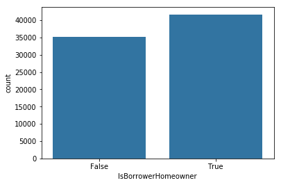

```python
#Distribution of home owners
sb.countplot(data=loan_df2, x="IsBorrowerHomeowner", color=base_color);
```

There are more home owners than non home owners

### Discuss the distribution(s) of your variable(s) of interest. Were there any unusual points? Did you need to perform any transformations?

- The Loan original amount has a multimodal distribution, with peaks around \$4K, \\$10K, \$15K, \\$20K, \$35K and the curve kind of flattens around \\$30K. These peak values occur almost in 5 thousands, almost like borrowers would 'round-up' their loan amounts.Most of the loans taken have values less that \$10,000, very few loans have values greater than $26,000.
- The histogram for shows a multimodal distribution, with peak values around 0.14, 0.26 and a sharp peak around 0.32. It shows most of the loans in the dataset have borrower rates around 0.26 and below.

### Of the features you investigated, were there any unusual distributions? Did you perform any operations on the data to tidy, adjust, or change the form of the data? If so, why did you do this?

> StatedMonthlyIncome was extremely skewed to the right due to the presence of outliers. I grouped some categories in some columns(EmploymentStatus, IncomeRange, LoanStatus) because they overlapped. I also created a new column to group levels of the credit score so I can have a better understanding of the distribution.

## Bivariate Exploration

```python
numeric_vars = ["BorrowerRate", "StatedMonthlyIncome", "MonthlyLoanPayment", "LoanOriginalAmount",
                         "DebtToIncomeRatio", "CreditScoreAverage"]
```

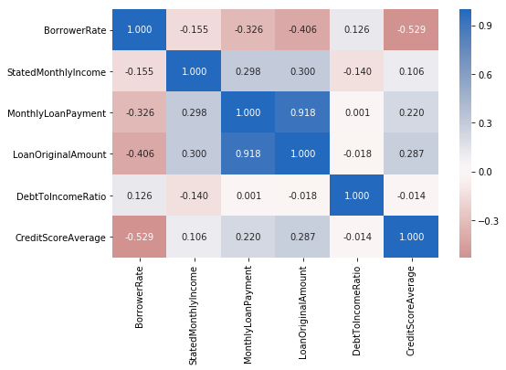

```python
# correlation plot of the numeric variables
plt.figure(figsize = [8, 5])
sb.heatmap(loan_df2[numeric_vars].corr(), annot = True, fmt = '.3f',
           cmap = 'vlag_r', center = 0)
plt.show()
```

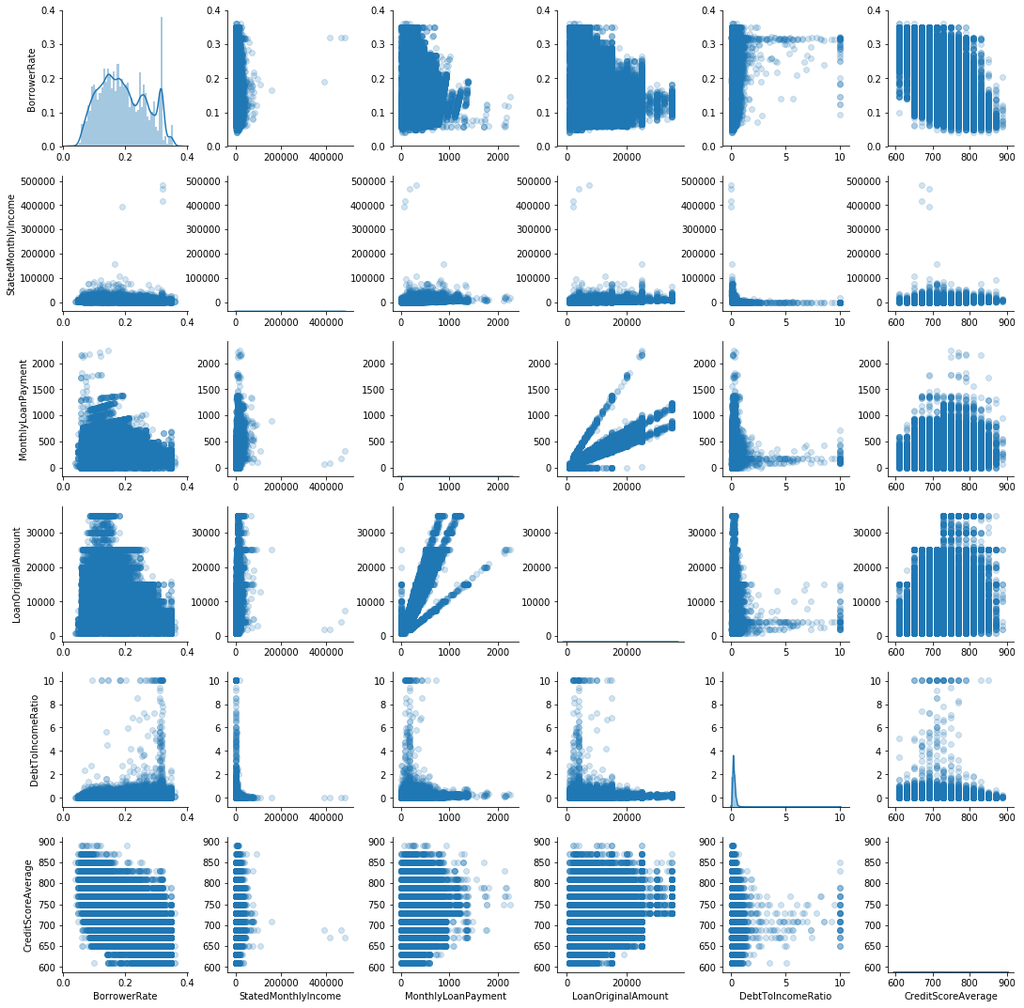

```python
#scatter plots of numeric variables

g = sb.PairGrid(loan_df2[numeric_vars])
g.map_diag(sb.distplot)
g.map_offdiag(plt.scatter, alpha=0.2);
```

Due to the outliers in the stated monthly income, I will regenerate some plots

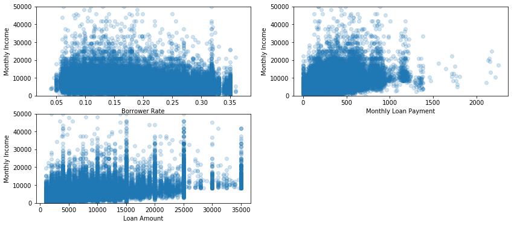

```python
plt.figure(figsize=(14,6))
plt.subplot(2,2,1)
plt.scatter(data=loan_df2, x="BorrowerRate", y="StatedMonthlyIncome", alpha=0.2)
plt.ylim(0,50000)
plt.xlabel("Borrower Rate")
plt.ylabel("Monthly Income")

plt.subplot(2,2,2)
plt.scatter(data=loan_df2, x="MonthlyLoanPayment", y="StatedMonthlyIncome", alpha=0.2)
plt.ylim(0,50000)
plt.xlabel("Monthly Loan Payment")
plt.ylabel("Monthly Income")

plt.subplot(2,2,3)
plt.scatter(data=loan_df2, x="LoanOriginalAmount", y="StatedMonthlyIncome", alpha=0.2)
plt.ylim(0,50000)
plt.xlabel("Loan Amount")
plt.ylabel("Monthly Income");
```

- Because there are few high income earners, from the plot it shows more earners between 25K nand 50K had rates less than 0.2, and less of earners between 25K and 50K had rates above 0.2. Generally, the plot does not show any particular pattern between Stated montly income and borrower rate.
- With monthly loan payment, it can be seen that generally, higher montly loan payments had lower interest rates, and the higher interest rates are associated with lower monthly payments.
- Higher laon amounts were associated with lower borrower rates of less than 0.2
- Borrowers with high debt to income ratio had had higher borrower rate around 0.32
- Most borrowers with the highest credit score range had interest rates less than 0.2, and those with the lowest credit score range had interest rates mostly greater than 0.2
- Generally, as expected, loan amount and monthly payment are positively correlated.
- Borrowers with low debt to income ratio borrowed the most, with those with high debt to income ratio borrowing less amounts, less than \$15K, which makes sense because it will be more likely to grant a loan to those who do not already have so much debt

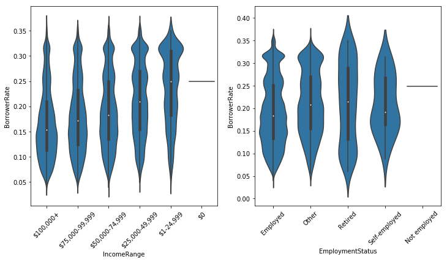

```python
#Borrower rate and income range
plt.figure(figsize=(12,6))
plt.subplot(1,2,1)
order = ["$100,000+", "$75,000-99,999", "$50,000-74,999", "$25,000-49,999", "$1-24,999", "$0"]
sb.violinplot(data=loan_df2, x="IncomeRange", y="BorrowerRate", color=base_color, order=order)
plt.xticks(rotation=45)

plt.subplot(1,2,2)
sb.violinplot(data=loan_df2, x="EmploymentStatus", y="BorrowerRate", color=base_color)
plt.xticks(rotation=45);
```

- Generally, as income range reduces, the median borrower rate increases. The plot shows that more borrowers in higher income ranges have lower borrower rates. Most high income earners(50K - 100K+) have interest rates lower than 0.25.
- Also, more people that are employed and self-employed have lower borrower rates

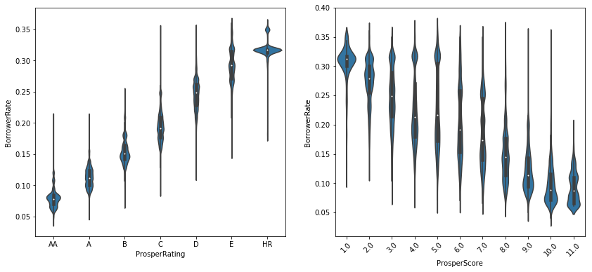

```python
#Borrower rate & Prosper rating/prosper score
plt.figure(figsize=(14,6))
plt.subplot(1,2,1)
sb.violinplot(data=loan_df2, x="ProsperRating", y="BorrowerRate", color=base_color)


plt.subplot(1,2,2)
sb.violinplot(data=loan_df2, x="ProsperScore", y="BorrowerRate", color=base_color)
plt.xticks(rotation=45);
```

- Borrowers with better Prosper ratings (A, AA) generally had lower interest rates, which might mean Prosper rewards borrowers with good Prosper ratings with lower borrower rates.
- Borrowers with higher risk scores(Prosper Score, best is 11, worst is 1) had lower interest rates, and those with lower risk scores had higher borrower rates

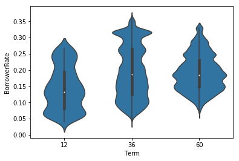

```python
#Borrower rate and term

sb.violinplot(data=loan_df2, x="Term", y="BorrowerRate", color=base_color);
```

Loans with longer terms generally have higher borrower rates, which makes sense because the longer the term, the higher the risk.

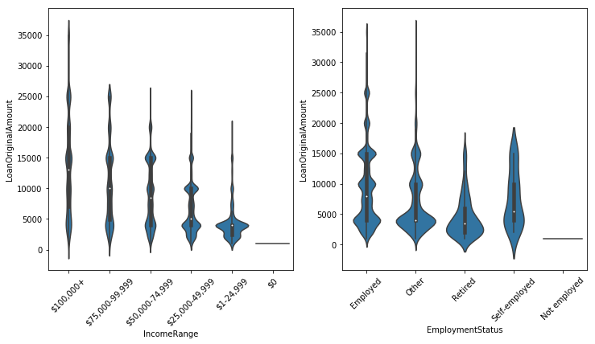

```python
#Loan Amount and income range/employment status
plt.figure(figsize=(12,6))
plt.subplot(1,2,1)
order = ["$100,000+", "$75,000-99,999", "$50,000-74,999", "$25,000-49,999", "$1-24,999", "$0"]
sb.violinplot(data=loan_df2, x="IncomeRange", y="LoanOriginalAmount", color=base_color, order=order)
plt.xticks(rotation=45)

plt.subplot(1,2,2)
sb.violinplot(data=loan_df2, x="EmploymentStatus", y="LoanOriginalAmount", color=base_color)
plt.xticks(rotation=45);
```

- As expected, lower income earners borrow smaller amounts.
- The most number of high loan amounts came from employed individuals.

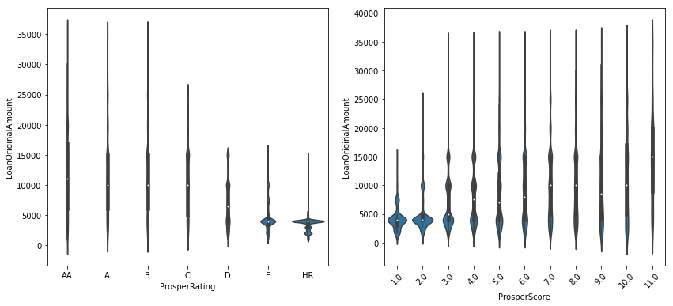

```python
#Loan Amount & Prosper rating/prosper score
plt.figure(figsize=(14,6))
plt.subplot(1,2,1)
sb.violinplot(data=loan_df2, x="ProsperRating", y="LoanOriginalAmount", color=base_color)


plt.subplot(1,2,2)
sb.violinplot(data=loan_df2, x="ProsperScore", y="LoanOriginalAmount", color=base_color)
plt.xticks(rotation=45);
```

- Most borrowers with poor ratings(E, HR) have low value loans, less than \$5K. The value of loans in each category reduces as the rating reduces.
- Also, the lower risk scores are more populated with lower value loans, the chances of getting a high value loan decreases as the ProsperScore decreases.

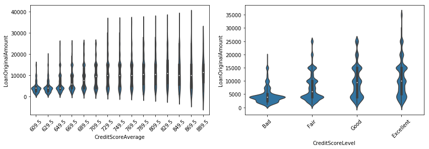

```python
#Loan amount and credit score
plt.figure(figsize=(14,4))
plt.subplot(1,2,1)
sb.violinplot(data=loan_df2, x="CreditScoreAverage", y="LoanOriginalAmount", color=base_color)
plt.xticks(rotation=45)

plt.subplot(1,2,2)
sb.violinplot(data=loan_df2, x="CreditScoreLevel", y="LoanOriginalAmount", color=base_color)
plt.xticks(rotation=45);
```

Borrowers with credit scores between 600 and 700 generally have more low value loan amounts. Borrowers with bad credit scores mostly received low value loans, less than \$5k. The proportion of low value loans in each level generally reduces as we move from bad to excellent.

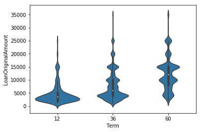

```python
#Loan Amount and term
sb.violinplot(data=loan_df2, x="Term", y="LoanOriginalAmount", color=base_color);
```

Most short term loans(12 months) are low value loans(<10K). Generally, the longer the term, the more likely it is to be a high value loan, as the median value for loans with term of 60 months is higher than those of 36 months, which in turn is higher than 12 months.

```python
#average loan amount and rate grouped by year
average_amount = loan_df2.groupby(loan_df2["LoanOriginationDate"].dt.year)["LoanOriginalAmount"].mean()
average_rate = loan_df2.groupby(loan_df2["LoanOriginationDate"].dt.year)["BorrowerRate"].mean()
```

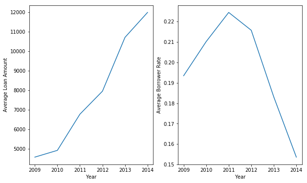

```python
#Trend of average loan amount and rate
plt.figure(figsize=(10,6))
plt.subplot(1,2,1)
average_amount.plot()
plt.xlabel("Year")
plt.ylabel("Average Loan Amount")

plt.subplot(1,2,2)
average_rate.plot()
plt.xlabel("Year")
plt.ylabel("Average Borrower Rate");
```

- The average loan amount shows an upward trend over the years
- For the average borrower rate, there is an increase in the average rate from 2009 to 2011, then a slight decrease from 2011 to 2012 and then a sharp decline from 2012 to 2014.
- From previous plots, I noticed that higher loan amounts generally had lower interest rates, so the above points follow since in 2014 the average loan amount was the highest, so lower average interest rate.

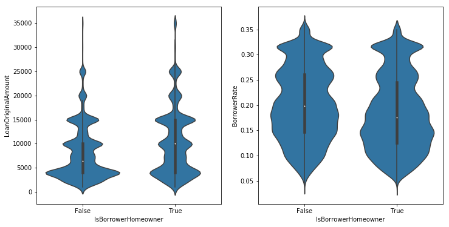

```python
plt.figure(figsize=(12,6))
plt.subplot(1,2,1)
sb.violinplot(data=loan_df2, x="IsBorrowerHomeowner", y="LoanOriginalAmount", color=base_color)

plt.subplot(1,2,2)
sb.violinplot(data=loan_df2, x="IsBorrowerHomeowner", y="BorrowerRate", color=base_color);
```

Home owners generally had lower proportion of low income loans than non home owners, which makes sense because their homes can serve as collateral, they also had higher proportion of lower borrower rates.

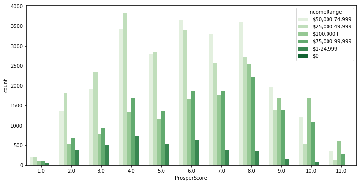

```python
#prosper score and income range
plt.figure(figsize=(12,6))
sb.countplot(data=loan_df2, hue= "IncomeRange", x="ProsperScore", palette="Greens");
```

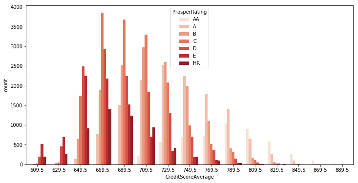

```python
#prosper rating and credit score
plt.figure(figsize=(12,6))
sb.countplot(data=loan_df2, hue= "ProsperRating", x="CreditScoreAverage", palette="Reds");
```

I now want to see how state relates with my variables of interest

```python
#Top 10 average income and rate per state
top_income = loan_df2.groupby("BorrowerState")["StatedMonthlyIncome"].mean().sort_values(ascending=False).head(10)
top_amount = loan_df2.groupby("BorrowerState")["LoanOriginalAmount"].mean().sort_values(ascending=False).head(10)

#Bottoom 10 average income and rate per state
bottom_income = loan_df2.groupby("BorrowerState")["StatedMonthlyIncome"].mean().sort_values(ascending=False).tail(10)
bottom_amount = loan_df2.groupby("BorrowerState")["LoanOriginalAmount"].mean().sort_values(ascending=False).tail(10)
```

```python
top_income_df = top_income.to_frame().reset_index()
top_income_df.rename(columns={"StatedMonthlyIncome":"AverageMonthlyIncome"}, inplace=True)
top_amount_df = top_amount.to_frame().reset_index()
top_amount_df.rename(columns={"LoanOriginalAmount":"AverageLoanAmount"}, inplace=True)

bottom_income_df = bottom_income.to_frame().reset_index()
bottom_income_df.rename(columns={"StatedMonthlyIncome":"AverageMonthlyIncome"}, inplace=True)
bottom_amount_df = bottom_amount.to_frame().reset_index()
bottom_amount_df.rename(columns={"LoanOriginalAmount":"AverageLoanAmount"}, inplace=True)
```

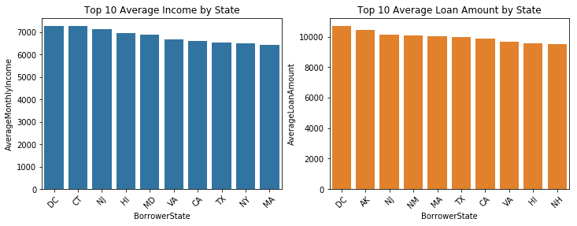

```python
plt.figure(figsize=(12,4))
plt.subplot(1,2,1)
sb.barplot(data=top_income_df, x="BorrowerState", y="AverageMonthlyIncome", color=base_color)
plt.xticks(rotation=45)
plt.title("Top 10 Average Income by State")

plt.subplot(1,2,2)
sb.barplot(data=top_amount_df, x="BorrowerState", y="AverageLoanAmount", color=sb.color_palette()[1])
plt.xticks(rotation=45)
plt.title("Top 10 Average Loan Amount by State");
```

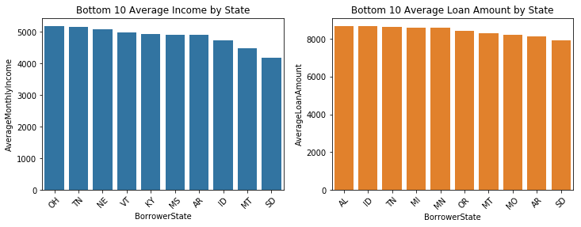

```python
plt.figure(figsize=(12,4))
plt.subplot(1,2,1)
sb.barplot(data=bottom_income_df, x="BorrowerState", y="AverageMonthlyIncome", color=base_color)
plt.xticks(rotation=45)
plt.title("Bottom 10 Average Income by State")

plt.subplot(1,2,2)
sb.barplot(data=bottom_amount_df, x="BorrowerState", y="AverageLoanAmount", color=sb.color_palette()[1])
plt.xticks(rotation=45)
plt.title("Bottom 10 Average Loan Amount by State");
```

From the plots above, 7 out of the top 10 states with the highest average monthly income are also part of the top 10 states with the highest loan amount. This follows from the earlier observation that people that earn more generally borrow higher amounts. Similarly, 5 out of the bottom 10 states with the least income are also in the bottom 10 with the lowest loan amount.

### Talk about some of the relationships you observed in this part of the investigation. How did the feature(s) of interest vary with other features in the dataset?

> I noticed that borrowers with higher income generally borrowed higher amounts and the higher loan amounts generally had lower borrower rates, also borrowers with better Prosper scores and ratings had lower borrower rates. The loan amount also increased generally as the credit score improved. Borrowers with higher loan amounts mostly had longer terms.

## Multivariate Exploration

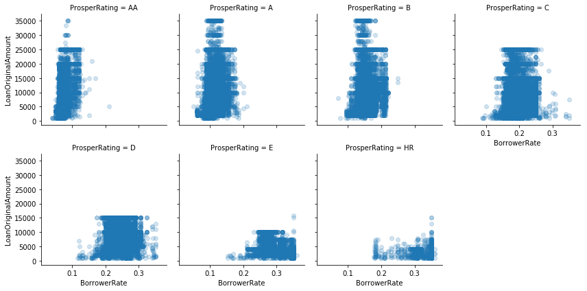

```python
#Borrower rate, loan amount, prosper score
g = sb.FacetGrid(data=loan_df2, col="ProsperRating", col_wrap=4)
g.map(plt.scatter, "BorrowerRate", "LoanOriginalAmount", alpha=0.2);
```

Borrower rates generally increase and the population of high income loan amounts reduce as the Prosper Rating gets worse.

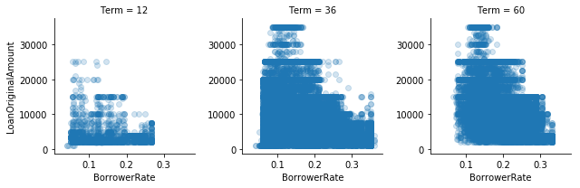

```python
g = sb.FacetGrid(data=loan_df2, col="Term")
g.map(plt.scatter, "BorrowerRate", "LoanOriginalAmount", alpha=0.2);
```

The highest loan amounts have terms of 36 and 60 months, and 12 months has the lowest interest rate

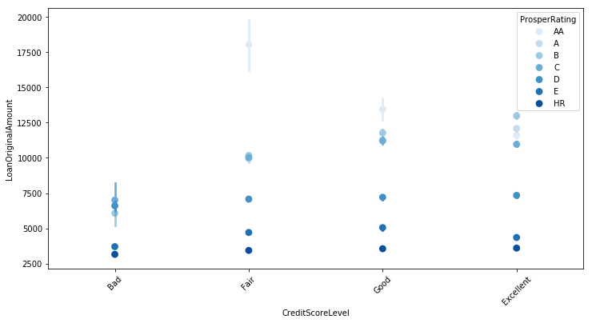

```python
#Credit score, Prosper  rating, loan amount
plt.figure(figsize=(12,6))
sb.pointplot(data = loan_df2, x = 'CreditScoreLevel', y = 'LoanOriginalAmount', hue = 'ProsperRating',
           palette = 'Blues', linestyles = '')
plt.xticks(rotation=45);
```

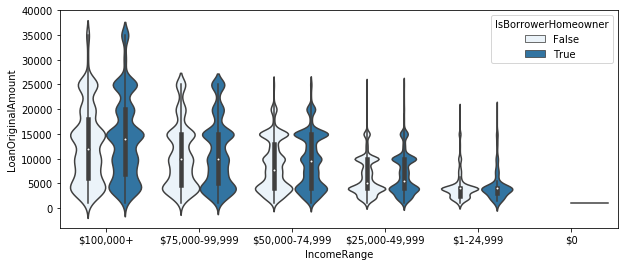

```python
order = ["$100,000+", "$75,000-99,999", "$50,000-74,999", "$25,000-49,999", "$1-24,999", "$0"]
plt.figure(figsize=(10,4))
sb.violinplot(data=loan_df2, x ="IncomeRange", y ="LoanOriginalAmount", hue ="IsBorrowerHomeowner", color = base_color, order=order);
```

There's a slight increase in the proportion of high value loans given to home owners than non home owners. A higher income and being a home owner might increase the chances of getting a high value loan.

### Were there any interesting or surprising interactions between features?

> I expected a very obvious difference between the value of loans gotten by home owners and those that are not home owners, due to thne fact that the homes can be used as collateral, also that there will be an obvious difference between home owners and non home owners in each income range but that was not the case.

## Conclusions

Generally, I observed that it is more likely to get high value loans and lower borrower rates if you have good credit score, lower borrower risk and good prosper rating, also shorter terms have lower borrower rates, and longer terms have higher loan amounts.